# ggcoefstats

## linear models for panel data (`plm`)

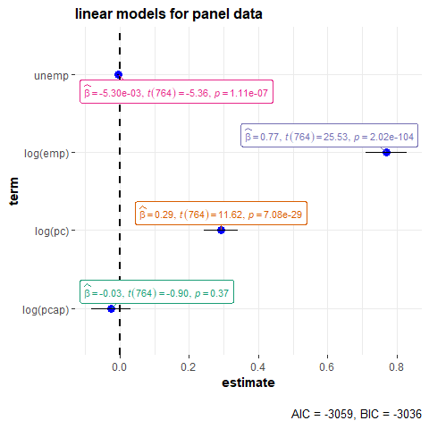

```r
# data
set.seed(123)
library(plm)
data("Produc", package = "plm")

# model
plm.mod <-
  plm::plm(
    formula = log(gsp) ~ log(pcap) + log(pc) + log(emp) + unemp,
    data = Produc,
    index = c("state", "year")
  )

# plot
ggcoefstats(
  x = plm.mod,
  title = "linear models for panel data"
)
```

## multinomial logit model (`mlogit`)

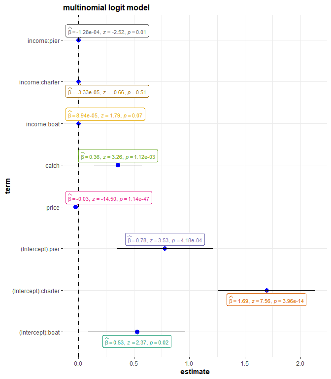

```r
# setup
set.seed(123)
library(mlogit)

# data
data("Fishing", package = "mlogit")
Fish <-
  mlogit::mlogit.data(Fishing,
    varying = c(2:9),
    shape = "wide",
    choice = "mode"
  )

# a "mixed" model
m_mlogit <- mlogit::mlogit(mode ~ price + catch | income, data = Fish)

# plot
ggcoefstats(
  x = m_mlogit,
  title = "multinomial logit model"
)
```

## Cox proportional hazards regression model (`coxph`)

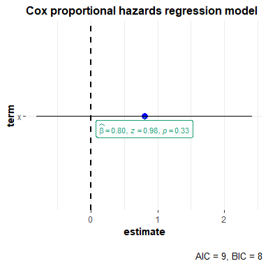

```r
# for reproducibility
set.seed(123)
library(survival)

# create the simplest-test data set
test1 <- list(
  time = c(4, 3, 1, 1, 2, 2, 3),
  status = c(1, 1, 1, 0, 1, 1, 0),
  x = c(0, 2, 1, 1, 1, 0, 0),
  sex = c(0, 0, 0, 0, 1, 1, 1)
)

# fit a stratified model
mod_coxph <-
  survival::coxph(
    formula = Surv(time, status) ~ x + strata(sex),
    data = test1
  )

# plot
ggcoefstats(
  x = mod_coxph,
  title = "Cox proportional hazards regression model"
)
```

Another example with `frailty` term.

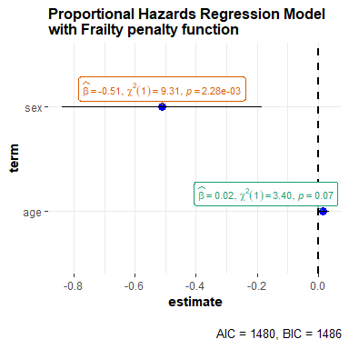

```r
# setup
set.seed(123)
library(survival)

# model
mod_coxph <- survival::coxph(
  formula = Surv(time, status) ~ age + sex + frailty(inst),
  data = lung
)

# plot
ggcoefstats(
  x = mod_coxph,
  title = "Proportional Hazards Regression Model\nwith Frailty penalty function"
)
```

## mixed effects Cox model (`coxme`)

```r
# setup
set.seed(123)
library(survival)
library(coxme)

# model
fit <- coxme::coxme(
  formula = Surv(y, uncens) ~ trt + (1 | center),
  data = eortc
)
```

```
#> Error in MASS::ginv(a): 'X' must be a numeric or complex matrix
```

[figure not shown]

```r
# plot
ggcoefstats(
  x = fit,
  title = "mixed effects Cox model"
)
```

## robust Cox proportional hazards regression model (`coxr`)

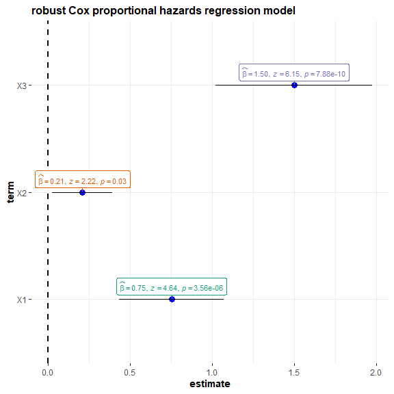

```r
# setup
set.seed(123)
library(coxrobust)

# create a simple test data set using the attached function `gen_data`
a <- coxrobust::gen_data(200, c(1, 0.1, 2), cont = 0.05, p.censor = 0.30)

# model
mod_coxr <- coxrobust::coxr(Surv(time, status) ~ X1 + X2 + X3, data = a, trunc = 0.9)

# plot
ggcoefstats(
  x = mod_coxr,
  title = "robust Cox proportional hazards regression model"
)
```

## truncated Gaussian Regression Models (`truncreg`)

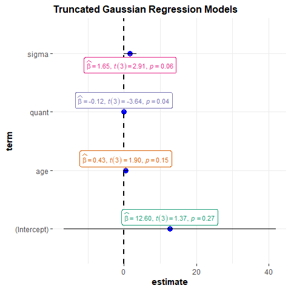

```r
# setup
set.seed(123)
library(truncreg)
library(survival)

# data
data("tobin", package = "survival")

# model
cragg_trunc <-
  truncreg::truncreg(
    formula = durable ~ age + quant,
    data = tobin,
    subset = durable > 0
  )

# plot
ggcoefstats(
  x = cragg_trunc,
  title = "Truncated Gaussian Regression Models"
)
```

## Fitting Linear Quantile Models

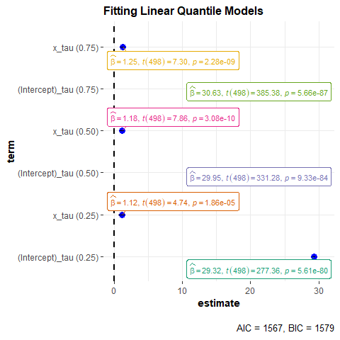

```r
# setup
set.seed(123)
library(lqmm)

# data
n <- 500
p <- 1:3 / 4
test <- data.frame(x = runif(n, 0, 1))
test$y <- 30 + test$x + rnorm(n)

# model
fit.lqm <-
  lqmm::lqm(
    y ~ x,
    data = test,
    tau = p,
    control = list(verbose = FALSE, loop_tol_ll = 1e-9),
    fit = TRUE
  )

# plot
ggcoefstats(
  x = fit.lqm,
  title = "Fitting Linear Quantile Models"
)
```

## Fitting Linear Quantile Mixed Models

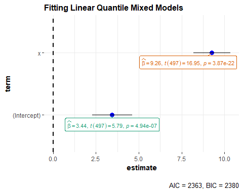

```r
# setup
set.seed(123)
library(lqmm)

# data
M <- 50
n <- 10
test <- data.frame(x = runif(n * M, 0, 1), group = rep(1:M, each = n))
test$y <- 10 * test$x + rep(rnorm(M, 0, 2), each = n) + rchisq(n * M, 3)

# model
fit.lqmm <-
  lqmm::lqmm(
    fixed = y ~ x,
    random = ~1,
    group = group,
    data = test,
    tau = 0.5,
    nK = 11,
    type = "normal"
  )

# plot
ggcoefstats(
  x = fit.lqmm,
  title = "Fitting Linear Quantile Mixed Models"
)
```

## autoregressive integrated moving average (`Arima`)

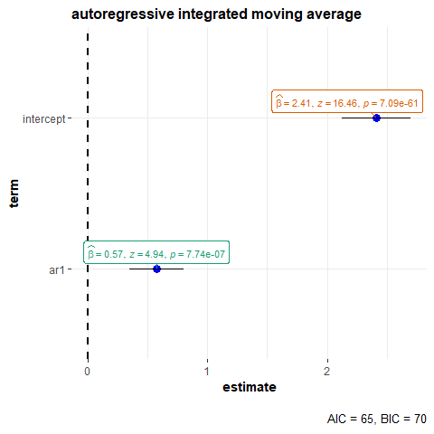

```r
# for reproducibility
set.seed(123)

# model
fit <- stats::arima(x = lh, order = c(1, 0, 0))

# plot
ggcoefstats(
  x = fit,
  title = "autoregressive integrated moving average"
)
```

## high performance linear model (`speedlm`/`speedglm`)

Example of high performance linear model-

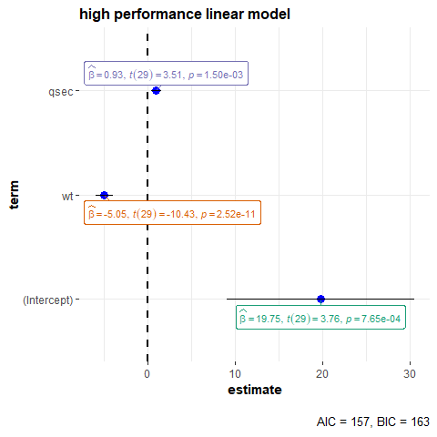

```r
# setup
library(speedglm)
set.seed(123)

# model
mod_speedlm <-
  speedglm::speedlm(
    formula = mpg ~ wt + qsec,
    data = mtcars,
    fitted = TRUE
  )

# plot
ggcoefstats(
  x = mod_speedlm,
  title = "high performance linear model"
)
```

Example of high performance generalized linear model-

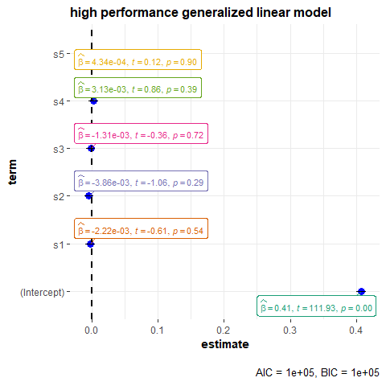

```r
# setup
set.seed(123)
library(speedglm)

# data
n <- 50000
k <- 5
y <- rgamma(n, 1.5, 1)
x <- round(matrix(rnorm(n * k), n, k), digits = 3)
colnames(x) <- paste("s", 1:k, sep = "")
da <- data.frame(y, x)
fo <- as.formula(paste("y~", paste(paste("s", 1:k, sep = ""), collapse = "+")))

# model
mod_speedglm <-
  speedglm::speedglm(
    formula = fo,
    data = da,
    family = stats::Gamma(log)
  )

# plot
ggcoefstats(
  x = mod_speedglm,
  title = "high performance generalized linear model"
)
```

## parametric survival regression model (`survreg`)

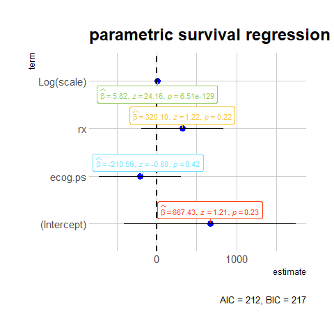

```r
# setup
set.seed(123)
library(survival)

# model
mod_survreg <-
  survival::survreg(
    formula = Surv(futime, fustat) ~ ecog.ps + rx,
    data = ovarian,
    dist = "logistic"
  )

# plot
ggcoefstats(
  x = mod_survreg,
  ggtheme = hrbrthemes::theme_ipsum_rc(),
  package = "ggsci",
  palette = "legacy_tron",
  title = "parametric survival regression model"
)
```

## Competing Risks Regression (`crr`)

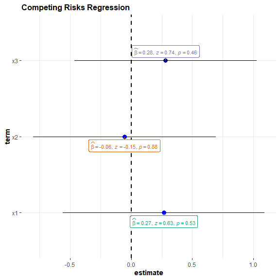

```r
# setup
set.seed(10)
library(cmprsk)

# simulated data to test
ftime <- rexp(200)
fstatus <- sample(0:2, 200, replace = TRUE)
cov <- matrix(runif(600), nrow = 200)
dimnames(cov)[[2]] <- c("x1", "x2", "x3")

# model
mod_crr <- cmprsk::crr(ftime, fstatus, cov)

# plot
ggcoefstats(
  x = mod_crr,
  title = "Competing Risks Regression"
)
```

## tobit regression (`tobit`)

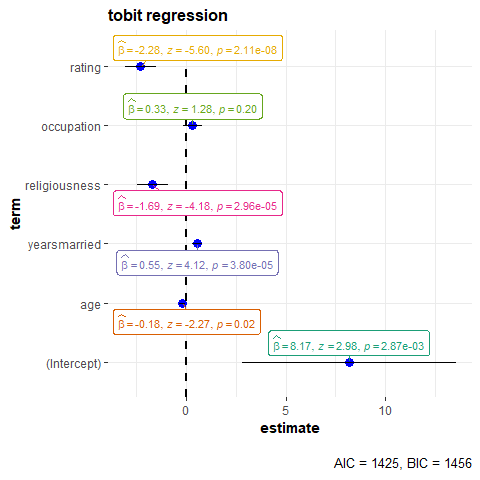

```r
# setup
set.seed(123)
library(AER)
data("Affairs", package = "AER")

# model
m_tobit <-
  AER::tobit(
    formula = affairs ~ age + yearsmarried + religiousness + occupation + rating,
    data = Affairs
  )

# plot
ggcoefstats(
  x = m_tobit,
  title = "tobit regression"
)
```

## censored regression (tobit) regression (`censReg`)

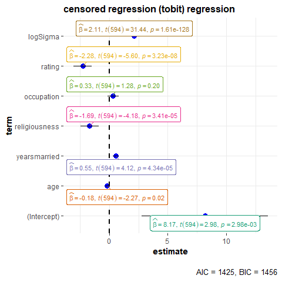

```r
# setup
set.seed(123)
library(censReg)
data("Affairs", package = "AER")

# model
estResult <-
  censReg::censReg(
    formula = affairs ~ age + yearsmarried + religiousness + occupation + rating,
    data = Affairs
  )

# plot
ggcoefstats(
  x = estResult,
  title = "censored regression (tobit) regression"
)
```

## relative risk regression model for case-cohort studies (`cch`)

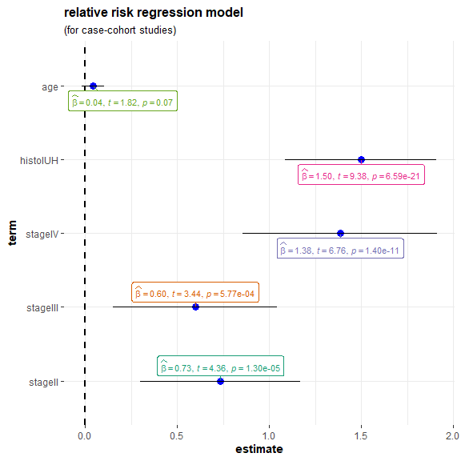

```r
# setup
set.seed(123)
library(survival)

# examples come from cch documentation
subcoh <- nwtco$in.subcohort
selccoh <- with(nwtco, rel == 1 | subcoh == 1)
ccoh.data <- nwtco[selccoh, ]
ccoh.data$subcohort <- subcoh[selccoh]

## central-lab histology
ccoh.data$histol <- factor(ccoh.data$histol, labels = c("FH", "UH"))

## tumour stage
ccoh.data$stage <- factor(ccoh.data$stage, labels = c("I", "II", "III", "IV"))
ccoh.data$age <- ccoh.data$age / 12 # Age in years

# model
fit.ccP <-
  survival::cch(
    formula = Surv(edrel, rel) ~ stage + histol + age,
    data = ccoh.data,
    subcoh = ~subcohort,
    id = ~seqno,
    cohort.size = 4028
  )

# plot
ggcoefstats(
  x = fit.ccP,
  title = "relative risk regression model",
  subtitle = "(for case-cohort studies)",
  conf.level = 0.99
)
```

## ridge regression (`ridgelm`)

For ridge regression, neither statistic values nor confidence intervals for estimates are available, so only estimates will be displayed.

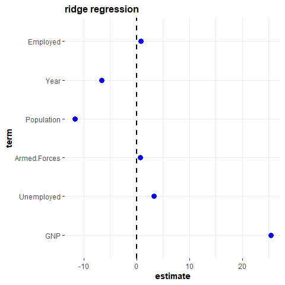

```r
# setup
set.seed(123)
library(MASS)

# model
names(longley)[1] <- "y"
mod_ridgelm <- MASS::lm.ridge(formula = y ~ ., data = longley)

# plot
ggcoefstats(
  x = mod_ridgelm,
  title = "ridge regression"
)
```

## generalized additive models with integrated smoothness estimation (`gam`)

**Important**: These model outputs contains both parametric and smooth terms. `ggcoefstats` only displays the parametric terms.

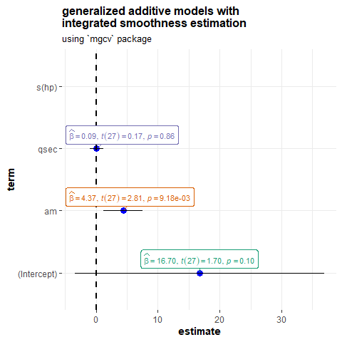

```r
# setup
set.seed(123)
library(mgcv)

# model
g_gam <-
  mgcv::gam(
    formula = mpg ~ s(hp) + am + qsec,
    family = stats::quasi(),
    data = mtcars
  )

# plot
ggcoefstats(
  x = g_gam,
  title = "generalized additive models with \nintegrated smoothness estimation",
  subtitle = "using `mgcv` package"
)
```

```r
# setup
set.seed(123)
library(mgcv)

# data
dat <- gamSim(1, n = 25000, dist = "normal", scale = 20)
```

```
#> Gu & Wahba 4 term additive model
```

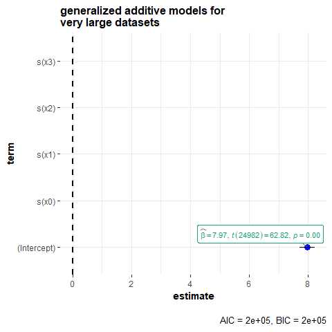

```r
bs <- "cr"
k <- 12

# model
b_bam <-
  mgcv::bam(
    formula = y ~ s(x0, bs = bs) + s(x1, bs = bs) + s(x2, bs = bs, k = k) +
      s(x3, bs = bs),
    data = dat
  )

# plot
ggcoefstats(
  x = b_bam,
  title = "generalized additive models for \nvery large datasets"
)
```

## generalized additive model (`Gam`)

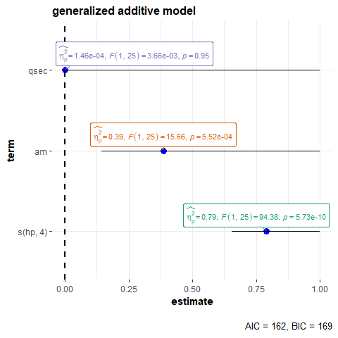

```r
# setup
set.seed(123)
library(gam)

# model
mod_gam <- gam::gam(
  formula = mpg ~ s(hp, 4) + am + qsec,
  data = mtcars
)

# plot
ggcoefstats(
  x = mod_gam,
  title = "generalized additive model",
  subtite = "(using `gam` package)"
)
```

## linear mixed-effects models (`lme`)

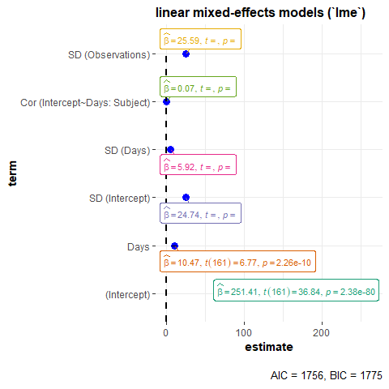

```r
# for reproducibility
set.seed(123)
library(lme4)
library(nlme)
data("sleepstudy")

# model
mod_lme <-
  nlme::lme(
    fixed = Reaction ~ Days,
    random = ~ 1 + Days | Subject,
    data = sleepstudy
  )

# plot
ggcoefstats(
  x = mod_lme,
  title = "linear mixed-effects models (`lme`)"
)
```

## linear model using generalized least squares (`gls`)

The `nlme` package provides a function to fit a linear model using generalized least squares. The errors are allowed to be correlated and/or have unequal variances.

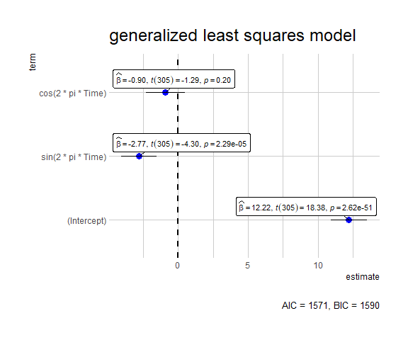

```r
# for reproducibility
set.seed(123)
library(nlme)

# model
mod_gls <-
  nlme::gls(
    model = follicles ~ sin(2 * pi * Time) + cos(2 * pi * Time),
    data = Ovary,
    correlation = corAR1(form = ~ 1 | Mare)
  )

# plot
ggcoefstats(
  x = mod_gls,
  stats.label.color = "black",
  ggtheme = hrbrthemes::theme_ipsum_ps(),
  title = "generalized least squares model"
)
```

## inference for estimated coefficients (`coeftest`)

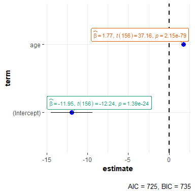

```r
# setup
set.seed(123)
library(lmtest)

# load data and fit model
data("Mandible", package = "lmtest")
fm <- stats::lm(formula = length ~ age, data = Mandible, subset = (age <= 28))

# the following commands lead to the same tests
ct <- lmtest::coeftest(fm)

# plot
ggcoefstats(
  x = ct,
  plot = "inference for estimated coefficients",
  conf.level = 0.99
)
```

## robust regression using an M estimator (`rlm`)

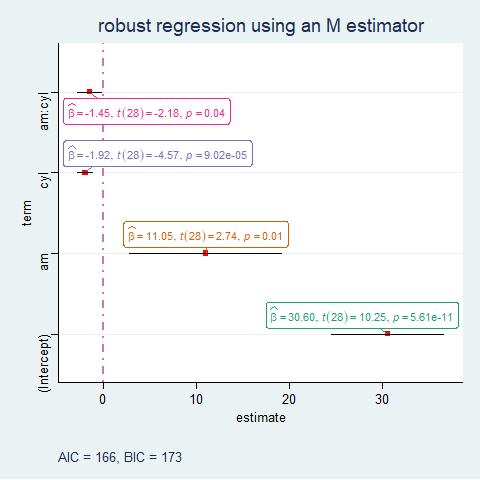

```r
# for reproducibility
set.seed(123)

# model
mod_rlm <- MASS::rlm(formula = mpg ~ am * cyl, data = mtcars)

# plot
ggcoefstats(
  x = mod_rlm,
  point.args = list(color = "red", shape = 15),
  vline.args = list(size = 1, color = "#CC79A7", linetype = "dotdash"),
  title = "robust regression using an M estimator",
  ggtheme = ggthemes::theme_stata()
)
```

## quantile regression (`rq`)

```r
# for reproducibility
set.seed(123)
library(quantreg)

# data
data(stackloss)

# model
mod_rq <-
  quantreg::rq(
    formula = stack.loss ~ .,
    data = stackloss,
    method = "br"
  )

# plot
ggcoefstats(
  x = mod_rq,
  se.type = "iid",
  title = "quantile regression"
)
```

```
#> Error: Problem with `mutate()` column `label`.
#> i `label = case_when(...)`.
#> x object 'df.error' not found
```

## multiple response quantile regression (`rqs`)

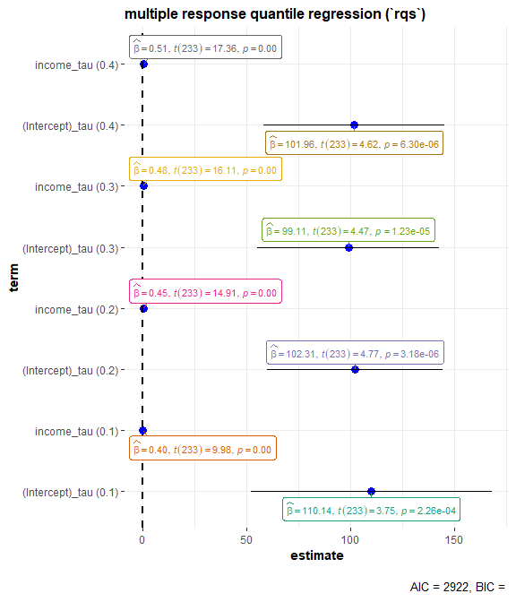

```r
# setup
set.seed(123)
library(quantreg)
data("engel")

# model
fm <-
  quantreg::rq(
    formula = foodexp ~ income,
    data = engel,
    tau = 1:4 / 10
  )

# plot
ggcoefstats(
  x = fm,
  title = "multiple response quantile regression (`rqs`)"
)
```

## nonlinear quantile regression estimates (`nlrq`)

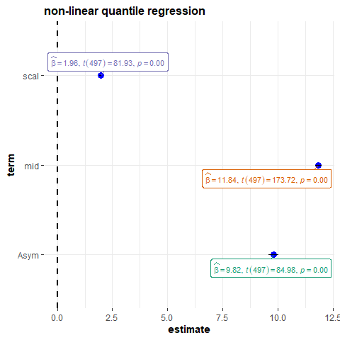

```r
# setup
set.seed(123)
library(quantreg)

# preparing data
Dat <- NULL
Dat$x <- rep(1:25, 20)
Dat$y <- stats::SSlogis(Dat$x, 10, 12, 2) * rnorm(500, 1, 0.1)

# then fit the median using nlrq
Dat.nlrq <-
  quantreg::nlrq(
    formula = y ~ SSlogis(x, Asym, mid, scal),
    data = Dat,
    tau = 0.5,
    trace = FALSE
  )

# plot
ggcoefstats(
  x = Dat.nlrq,
  title = "non-linear quantile regression",
  se.type = "nid"
)
```

## additive quantile regression (`rqss`)

```r
# setup
set.seed(123)
library(quantreg)
data(CobarOre)

# model
fCO <- quantreg::rqss(
  formula = z ~ qss(cbind(x, y), lambda = .08),
  data = CobarOre
)

# model info
ggcoefstats(
  x = fCO,
  title = "Additive Quantile Regression"
)
```

[figure not shown]

## censored quantile regression (`crq`)

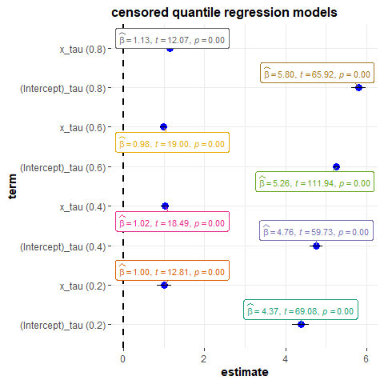

```r
# crq example with left censoring
set.seed(1968)
library(quantreg)

# data
n <- 200
x <- rnorm(n)
y <- 5 + x + rnorm(n)
c <- 4 + x + rnorm(n)
d <- (y > c)

# model
f_crq <- quantreg::crq(survival::Surv(pmax(y, c), d, type = "left") ~ x,
  method = "Portnoy"
)

# plot
ggcoefstats(
  x = f_crq,
  title = "censored quantile regression models"
)
```

## instrumental-variable regression (`ivreg`)

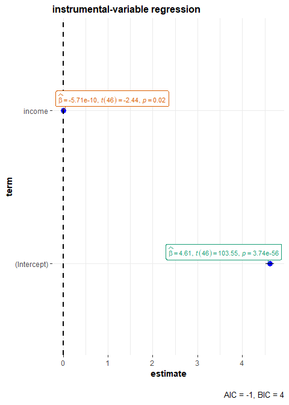

```r
# setup
suppressPackageStartupMessages(library(AER))
set.seed(123)
data("CigarettesSW", package = "AER")

# model
ivr <-
  AER::ivreg(
    formula = log(packs) ~ income | population,
    data = CigarettesSW,
    subset = year == "1995"
  )

# plot
ggcoefstats(
  x = ivr,
  title = "instrumental-variable regression"
)
```

## instrumental variables probit regression (`ivprobit`)

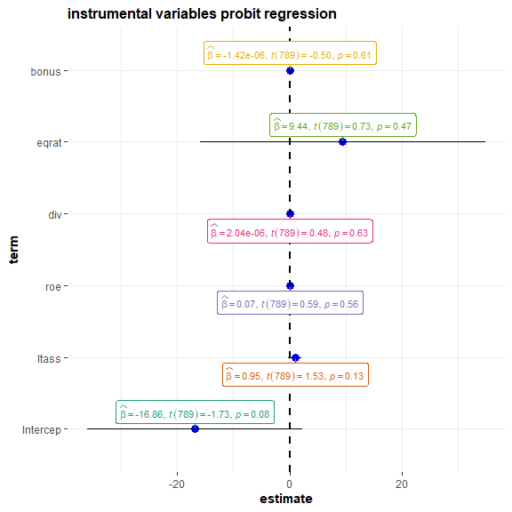

```r
# setup
set.seed(123)
library(ivprobit)
data(eco)

# model
pro <-
  ivprobit::ivprobit(
    formula = d2 ~ ltass + roe + div | eqrat + bonus | ltass + roe + div + gap + cfa,
    data = eco
  )

# plot
ggcoefstats(
  x = pro,
  title = "instrumental variables probit regression"
)
```

## instrumental fixed effect panel regression (`ivFixed`)

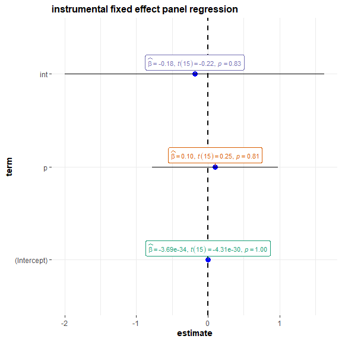

```r
# setup
set.seed(123)
library(ivfixed)

#  data
pib <- as.matrix(c(12, 3, 4, 0.4, 0.7, 5, 0.7, 0.3, 0.6, 89, 7, 8, 45, 7, 4, 5, 0.5, 5),
  nrows = 18,
  ncols = 1
)
tir <- as.matrix(c(12, 0.3, 4, 0.4, 7, 12, 3.0, 6.0, 45, 7.0, 0.8, 44, 65, 23, 4, 6, 76, 9),
  nrows = 18,
  ncols = 1
)
inf <- as.matrix(c(1.2, 3.6, 44, 1.4, 0.78, 54, 0.34, 0.66, 12, 0.7, 8.0, 12, 65, 43, 5, 76, 65, 8),
  nrows = 18,
  ncols = 1
)
npl <- as.matrix(c(0.2, 3.8, 14, 2.4, 1.7, 43, 0.2, 0.5, 23, 7.8, 88, 36, 65, 3, 44, 65, 7, 34),
  nrows = 18,
  ncols = 1
)
mdata <- data.frame(p = pib, t = tir, int = inf, np = npl)

# model
ivf <- ivfixed::ivFixed(t ~ p + int | p + np, mdata, n = 6, t = 3)

# plot
ggcoefstats(
  x = ivf,
  title = "instrumental fixed effect panel regression"
)
```